#### Important note: This report provides preliminary results and is work in progress (also see ‘Notes on individual reports’).

### Introduction

Switzerland reported its first case of coronavirus disease 2019 (COVID-19) on 25 Feb 2020. As of 23 Mar 2020, there are 8743 reported cases and 117 deaths. Arguably, the reported numbers of cases do not provide a clear picture of the overall epidemic as a significant proportion of particularly mild or asymptomatic cases cannot be diagnosed and will go unreported (also see [here](https://cmmid.github.io/topics/covid19/severity/global_cfr_estimates.html)). Hence, we argue that tracking the reported number of deaths provides a better picture of the COVID-19 epidemic in Switzerland. We fit a dynamic transmission model to the daily number of reported deaths in Switzerland, and project different future trajectories as a result of the lockdown ‘light’ on 17 Mar 2020.

### Methods

We consider a SEIR transmission model with additional compartments for hospitalization and critical care (ICU) (see R Markdown file and Table). We use a maximum likelihood framework to fit the model to the reported numbers of deaths, assuming the daily numbers of deaths are Poisson distributed. We assume constant uncontrolled transmission until the lockdown and then vary the transmission rate relative to the epidemic spread before the lockdown.

**Table. Parameters of the COVID-19 transmission model.**

[output not shown]

### Results

Before the lockdown in Switzerland, we estimate the basic reproduction number $R_0$ of COVID-19 at 3.12 (95% confidence interval: 2.49 - 3.84). This value of $R_0$ requires transmission to be reduced by at least 68% (1 - 1/$R_0$) in order to drop the effective reproduction number $R$ below the critical threshold of 1.

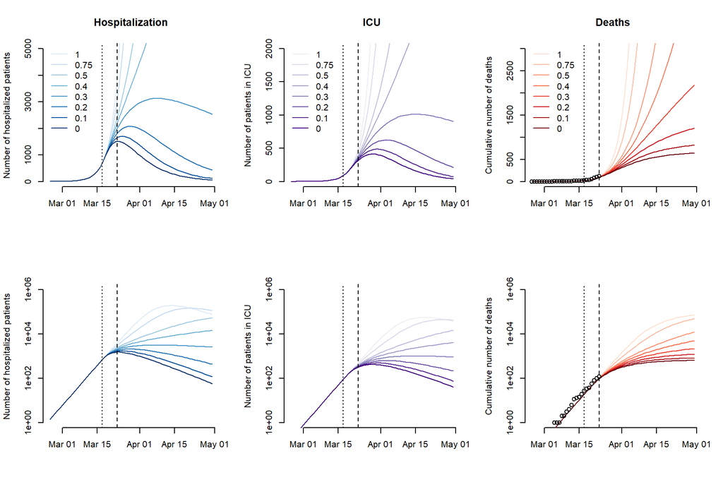

**Figure. Projected numbers of hospitalizations, patients in ICU and deaths under different scenarios for the COVID-19 epidemic in Switzerland.** The different scenarios correspond to different levels of transmission relative to the epidemic spread before the lockdown. Vertical dotted and dashed lines indicate the time points of the lockdown (17 Mar 2020) and the last data point (23 Mar 2020). Epidemic trajectories are shown on a linear (top panels) and logarithmic (bottom panels) scale.

### Notes on individual reports

- 24 Mar 2020: Shortening the generation time from 7.5 days ([Li et al.](https://doi.org/10.1056/NEJMoa2001316)) to 5.2 days ([Ganyani et al.](https://www.medrxiv.org/content/10.1101/2020.03.05.20031815v1)) results in a lower estimate of $R_0$, and consequently more optimistic projections about epidemic control.